# K-means

La primera parte de esta práctica tiene como objetivo proporcionar una comprensión sobre el uso del paquete `sklearn.cluster.KMeans` el cual utilizaremos como implementacion del algoritmo de M-means sobre datos generados de manera sintetica ayudados del paquete `sklearn.datasets.make_blobs` y `sklearn.datasets.make_circles`. Para mas informacion de estas dos herramientas pueden consultar: https://scikit-learn.org/stable/user_guide.html

```python
#Importar paquetes
import numpy as np
import matplotlib.pyplot as plt

from sklearn.cluster import KMeans
from sklearn.datasets import make_blobs, make_circles

from imblearn.over_sampling import SMOTE

from sklearn.metrics import silhouette_score,silhouette_samples
from yellowbrick.cluster import SilhouetteVisualizer
```

## a) Generación de datos:

Utilizaremos make_blobs para crear 4 dataset con propiedades distintas (**Nota**: Esta subsección está completamente terminada no es necesario cambiar el código)

```python
n_samples = 1500
random_state = 123

#DataSet 1
X, y = make_blobs(n_samples=n_samples, random_state=random_state)

#DataSet 2
X_varied, y_varied = make_blobs(n_samples=n_samples, cluster_std=[1.0, 2.5, 0.5], random_state=random_state)

#DataSet 3
X_filtered = np.vstack((X[y == 0][:500], X[y == 1][:100], X[y == 2][:10]))
y_filtered = [0] * 500 + [1] * 100 + [2] * 10

#DataSet 4
X_circle, y_circle = make_circles(n_samples=n_samples, random_state=random_state,noise=0.1,factor=0.5)
```

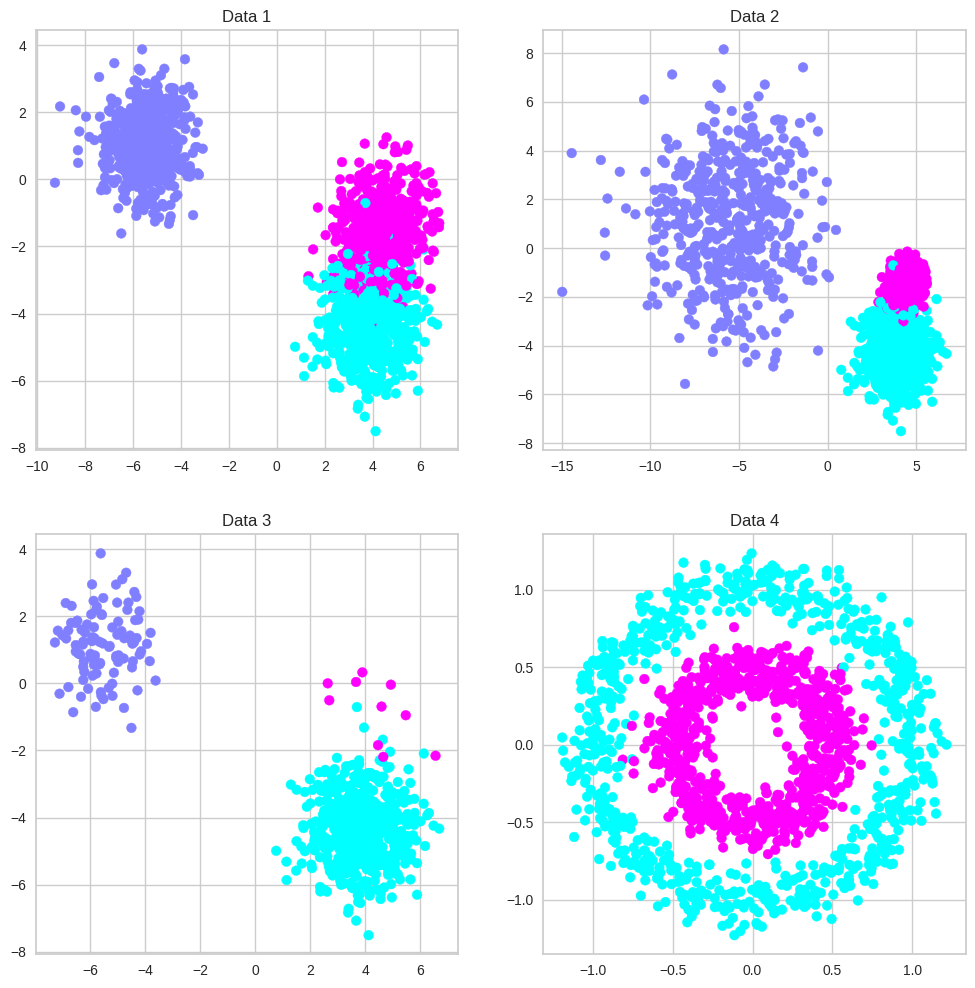

```python
fig, axs = plt.subplots(nrows=2, ncols=2, figsize=(12, 12))
axs[0, 0].scatter(X[:, 0], X[:, 1], c=y,cmap="cool")
axs[0, 0].set_title("Data 1")

axs[0, 1].scatter(X_varied[:, 0], X_varied[:, 1], c=y_varied,cmap="cool")
axs[0, 1].set_title("Data 2")

axs[1, 0].scatter(X_filtered[:, 0], X_filtered[:, 1], c=y_filtered,cmap="cool")
axs[1, 0].set_title("Data 3")

axs[1, 1].scatter(X_circle[:, 0], X_circle[:, 1], c=y_circle,cmap="cool")
axs[1, 1].set_title("Data 4")

plt.show()
```

### Pregunta 1: Explica cuales son las principales características de cada dataset, además explica si el algoritmo k-mean podrá agrupar los datos presentados, justifica tu respuesta.

En el **dataset 1** vemos la presencia de tres clusters, todos ellos presentan una gran concentración. Uno de ellos está separado de los otros dos y los dos restantes están prácticamente fusionados.

Dado que el tamaño de los cluster y sus varianzas son similares, k-means realizará una buena agrupación. No obstante, al haber dos grupos muy juntos podría surgir problemas para separar uno d otro.

En el **dataset 2** también observamos 3 clusters, el más alejado tiene puntos más dispersos. Sin embargo, los dos restantes están mucho más concentrados, uno tiene mayor dimensión y el otro es más pequeño. Estos dos se encuentran prácticamente fusionados.

Dado que los tres clusters presentan el mismo número de cluster pero sus varianzas son distintas, es posible que el alogritmo k-means asigne los puntos más externos al cluster de mayor varaianza a los otros clusters.

En el **dataset 3** volvemos a observar 3 clusters, pero en este caso encontramos uno con muchas muestras cercano a otro que presnta pocas muestras. El cluster restante está más alejado y presenta menos muestras que el grande y más que el pequeño.

Dado que existe un cluster con muchas más muestras que el resto, es posible que al aplicar k-means, el algoritmo identifique que el cluster con menos muestras pertenece al cluster más grande.

En el **dataset 4** vemos dos clusters los cuales se distribuyen en forma de dos circunferencias concéntricas.

Dado que k-means agrupa en hiperesferas, será imposible que el resultado del agrupamiento sea bueno.

# b) Implementación de K-mean:

Esta sección se centra en la implementación del algoritmo de k-means, usa como referencia el siguiente código para **procesar cada una de las bases de datos**.

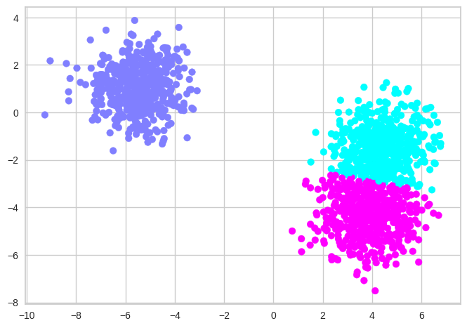

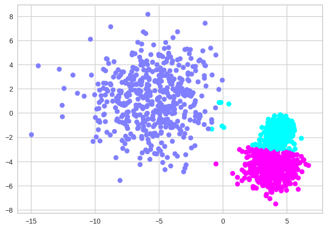

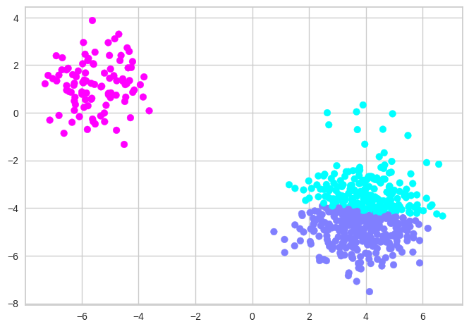

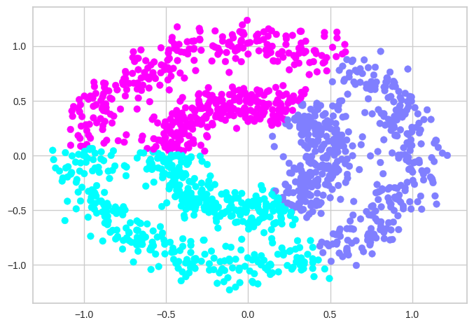

```python
from sklearn.cluster import KMeans
import matplotlib.pyplot as plt

# Para el dataset 1
y_pred = KMeans(n_clusters=3, random_state=123, init='random').fit_predict(X)
plt.scatter(X[:, 0], X[:, 1], c=y_pred, cmap = 'cool')
plt.show()

# Para el dataset 2
y_pred2 = KMeans(n_clusters=3, random_state=random_state, init='random').fit_predict(X_varied)
plt.scatter(X_varied[:, 0], X_varied[:, 1], c=y_pred2, cmap="cool")
plt.show()

# Para el dataset 3
y_pred3 = KMeans(n_clusters=3, random_state=random_state, init='random').fit_predict(X_filtered)
plt.scatter(X_filtered[:, 0], X_filtered[:, 1], c=y_pred3, cmap="cool")
plt.show()

# Para el dataset 4
y_pred4 = KMeans(n_clusters=3, random_state=random_state, init='random').fit_predict(X_circle)
plt.scatter(X_circle[:, 0], X_circle[:, 1], c=y_pred4, cmap="cool")
plt.show()
```

### Pregunta 2: Discute los resultados obtenidos y compararlos con tu analisis realizado en la pregunta anterior.

Como ya hemos dicho anteriormente, los clusters de el dataset 1 tiene un buen agrupamiento excepto en la frontera entre los clusters más cercanos.

En el dataset 2 las muestras más alejadas del centroide del clsuter más disperso se agruparan en los otros dos clusters.

En el dataset3 vemos que la clusterización agrupa en el mismo cluster al que más y al que menos puntos tiene, y al fijar n_clusters con valor 3, divide este nuevo cluster en dos distintos.

En el dataset, como habíamos dicho el agrupamiento de este dataset será malo, ya que divide las circunferencias en porciones tirangulares y no las circunferencias entre si.

### Pregunta 3: Explica los parámetros `n_clusters=3`, `random_state=123` e `init='random'` y cómo influyen en las predicciones.

El parámetro n_clusters es aquel que maracmos el númeor de clusters que tiene que tener nuestro agrupamiento.

El parámetro init determina como elegir el primer centroide, si init tiene valor random se elegirá aleatoriamente.

El parámetro random_state sirve para fijar una semilla y que cada vez que ejecutemos el código se elija el mismo valor de centroide en caso de tener init='random'.

# c) Selección de `n_clusters`:

En esta sección veremos cómo afecta a nuestra predicción el parámetro `n_clusters`, para ello **toma el DataSet 2 y muestra las gráficas para distintos valores de `n_clusters`, iniciando desde 2 hasta 5**.

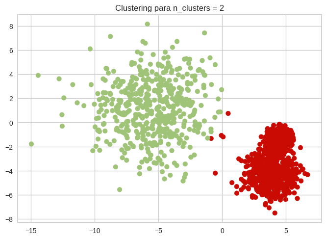

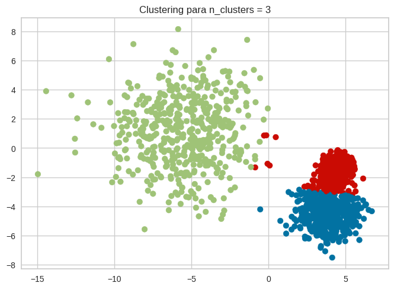

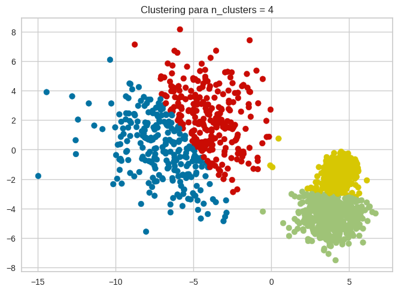

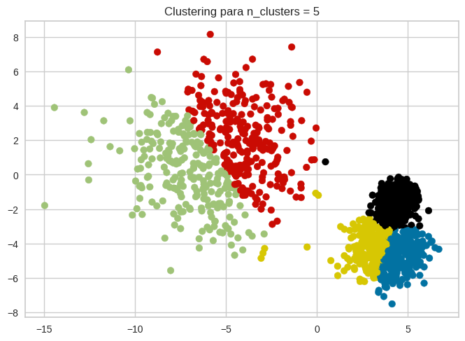

```python
import matplotlib.pyplot as plt
from sklearn.cluster import KMeans
from sklearn.datasets import make_blobs

n_samples = 1500
random_state = 123

X_varied, y_varied = make_blobs(n_samples=n_samples, cluster_std=[1.0, 2.5, 0.5], random_state=random_state)

# Definir una lista de colores para los clusters
colors = ['r', 'g', 'b', 'y', 'black']

# Prueba de diferentes valores de n_clusters
for n_clusters in range(2, 6):
    y_pred = KMeans(n_clusters=n_clusters, random_state=random_state, init='random').fit_predict(X_varied)
    plt.scatter(X_varied[:, 0], X_varied[:, 1], c=[colors[i] for i in y_pred])
    plt.title(f'Clustering para n_clusters = {n_clusters}')
    plt.show()
```

### Pregunta 4: Es posible que en un problema real no contemos con la información de la clase de cada muestra (los diferentes colores), ¿Hay algún valor de `n_clusters` que visualmente haga un buen agrupamiento sin tomar en cuenta los colores verdaderos? Detalla tu respuesta

Visualmente el agrupamiento de 2 clsuters es el que genera mejor agrupamiento a nuetsro parecer. Ya que distingue entre dos grupos bien diferenciados y no divide ningún grupo en dos de forma forzada.

Visualmente podemos comparar los resultados con las etiquetas reales en este problema gracias a su baja dimensionalidad y complejidad, sin embargo esto no es algo usual, por lo que tomar la decisión de cuántos clusters es el número correcto es más complicado. En este apartado veremos dos herramientas que pueden ayudar a tomar una decisión `silhouette_score` e `inertia` (Elbow Curve).

- **Silhouette** Es un indicador de la calidad de los clusters obtenidos en términos de cómo son de similares los datos en el mismo cluster respecto de los datos que están en otros clusters. Relaciona las distancias intra-cluster con las distancias inter-clusters. Es un indicador adecuado para K-Means porque, como sabemos, éste trata de minimizar las distancias intra-cluster de los datos. El indicador (Score) Silhouette se calcula para cada dato del dataset. Para ello se calculan para cada dato $p$ de los clusters obtenidos por K-Means las siguientes cantidades: Distancia media de las distancias entre el punto $p$ y el resto de puntos del cluster. La llamamos $a$. Distancia media de la distancia entre cada punto de un cluster y los puntos del cluster más cercano. La llamamos $b$ El indicador (Score) Silhouette $S$ para cada punto $p$ se calcula como se define como: $$S_p = \frac{(b - a)}{max(a, b)}$$
- **Elbow Curve** representa de manera gráfica el valor de la suma de las distancias al cuadrado de las muestras al centro de su grupo más cercano (inertia) para cada valor de cluster utilizado

**Usa como ejemplo el siguiente código para replicarlo en el resto de bases de datos**

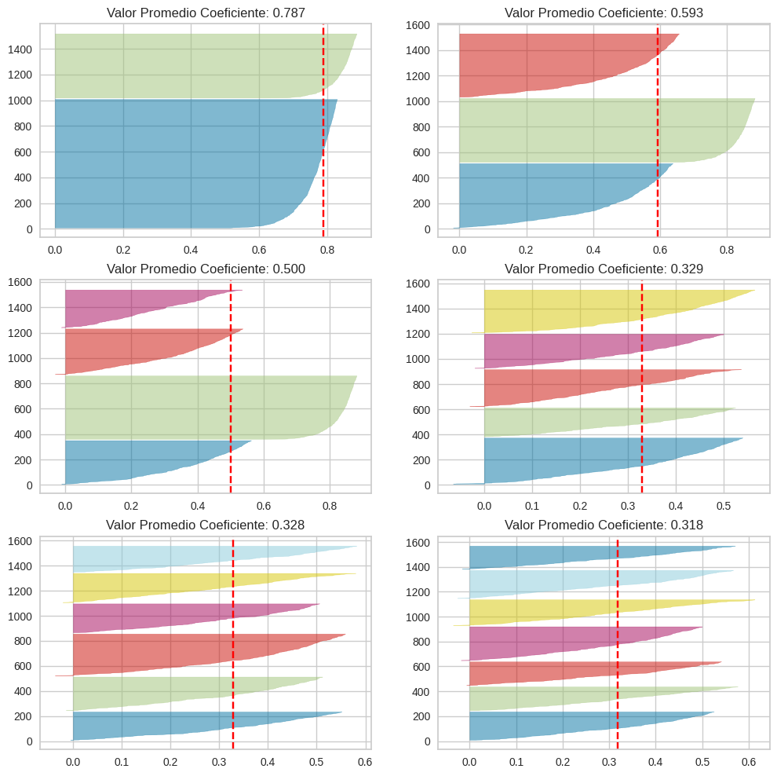

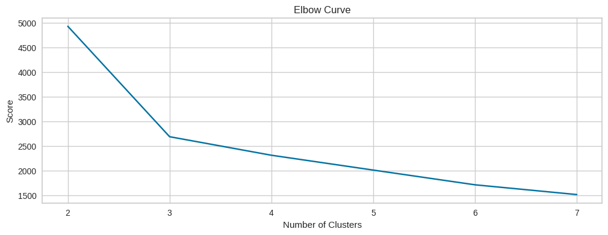

```python
#Dataset 1

#Seleccionamos un rango de clusters a analizar
n_clusters=[2, 3, 4, 5, 6, 7]

fig, ax = plt.subplots(3, 2, figsize=(12,12))
scores=[]
for c in n_clusters:
    #definimos el metodo KMeans
    km = KMeans(n_clusters=c, init='k-means++', n_init=10, random_state=123)
    q, mod = divmod(c, 2)
    km.fit(X)

    #recolectamos en un vector los valores de inertia
    scores.append(km.inertia_)

    #calculamos el silhouette score y mostramos su grafica
    score = silhouette_score(X, km.labels_, metric='euclidean')
    visualizer = SilhouetteVisualizer(km, colors='yellowbrick', ax=ax[q-1][mod])
    leyenda= "Valor Promedio Coeficiente: %.3f" % (score)
    visualizer.set_title(leyenda)
    visualizer.fit(X)
plt.show()

#Graficamos los valores de inertia para cada numero de cluster
plt.figure(figsize=(12,4))
plt.xlabel('Number of Clusters')
plt.ylabel('Score')
plt.title('Elbow Curve')
plt.plot(n_clusters,scores)
plt.show()
```

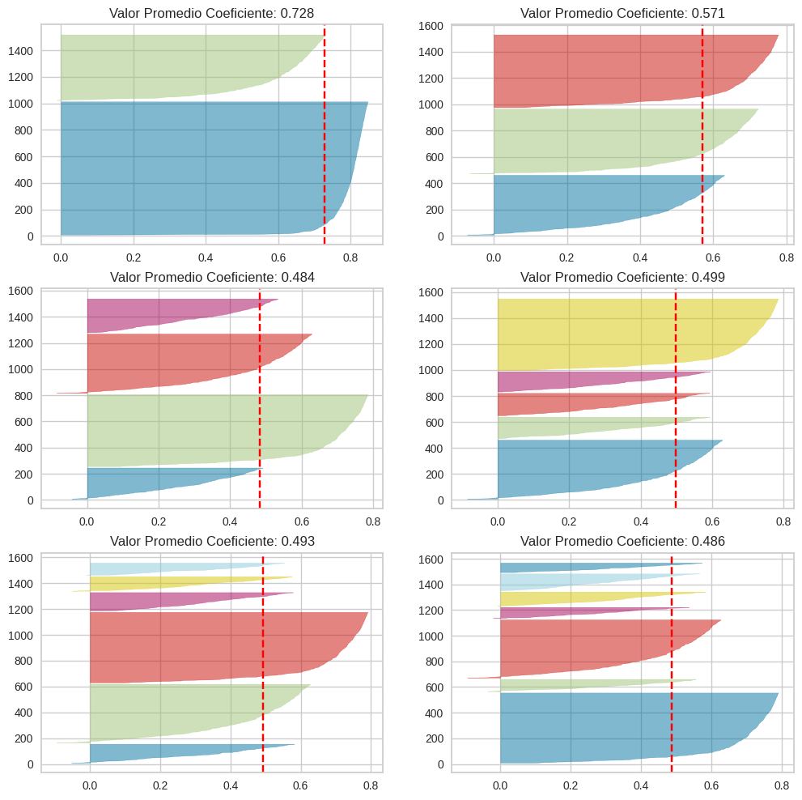

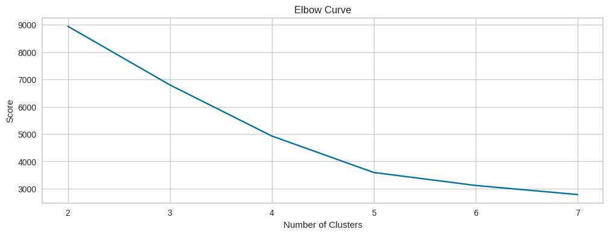

```python
# Para el dataset 2

# Seleccionamos un rango de clusters a analizar
n_clusters = [2, 3, 4, 5, 6, 7]

fig, ax = plt.subplots(3, 2, figsize=(12, 12))
scores = []
for c in n_clusters:
    # Definimos el método KMeans
    km = KMeans(n_clusters=c, init='k-means++', n_init=10, random_state=123)
    q, mod = divmod(c, 2)
    km.fit(X_varied)

    # Recolectamos en un vector los valores de inertia
    scores.append(km.inertia_)

    # Calculamos el silhouette score y mostramos su gráfica
    score = silhouette_score(X_varied, km.labels_, metric='euclidean')
    visualizer = SilhouetteVisualizer(km, colors='yellowbrick', ax=ax[q - 1][mod])
    leyenda = "Valor Promedio Coeficiente: %.3f" % (score)
    visualizer.set_title(leyenda)
    visualizer.fit(X_varied)

plt.show()

# Graficamos los valores de inertia para cada número de cluster
plt.figure(figsize=(12, 4))
plt.xlabel('Number of Clusters')
plt.ylabel('Score')
plt.title('Elbow Curve')
plt.plot(n_clusters, scores)
plt.show()
```

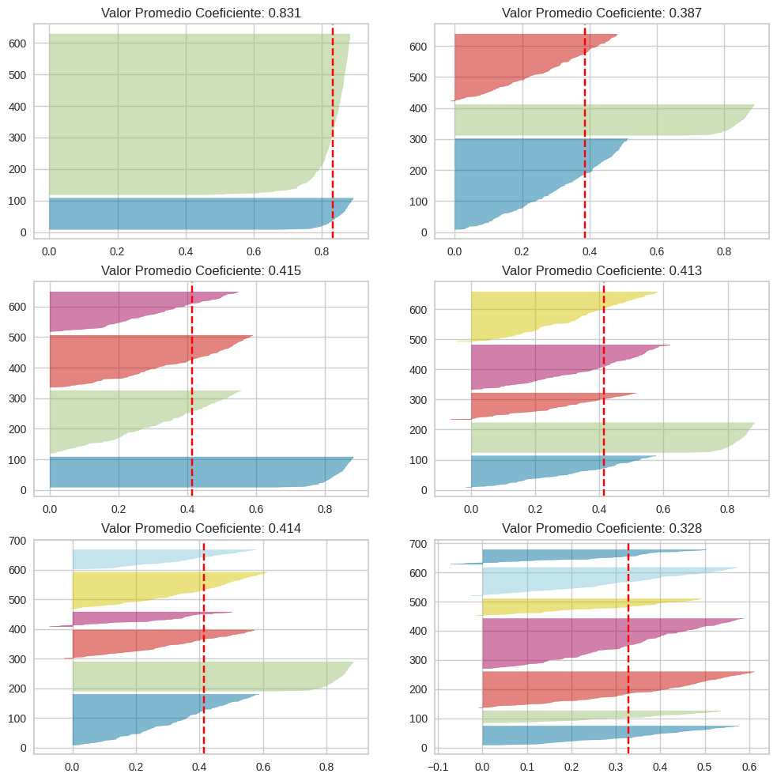

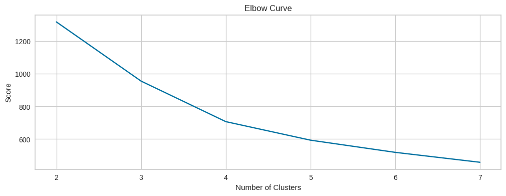

```python
# Para el dataset 3

# Seleccionamos un rango de clusters a analizar
n_clusters = [2, 3, 4, 5, 6, 7]

fig, ax = plt.subplots(3, 2, figsize=(12, 12))
scores = []
for c in n_clusters:
    # Definimos el método KMeans
    km = KMeans(n_clusters=c, init='k-means++', n_init=10, random_state=123)
    q, mod = divmod(c, 2)
    km.fit(X_filtered)

    # Recolectamos en un vector los valores de inertia
    scores.append(km.inertia_)

    # Calculamos el silhouette score y mostramos su gráfica
    score = silhouette_score(X_filtered, km.labels_, metric='euclidean')
    visualizer = SilhouetteVisualizer(km, colors='yellowbrick', ax=ax[q - 1][mod])
    leyenda = "Valor Promedio Coeficiente: %.3f" % (score)
    visualizer.set_title(leyenda)
    visualizer.fit(X_filtered)

plt.show()

# Graficamos los valores de inertia para cada número de cluster
plt.figure(figsize=(12, 4))
plt.xlabel('Number of Clusters')
plt.ylabel('Score')
plt.title('Elbow Curve')
plt.plot(n_clusters, scores)
plt.show()
```

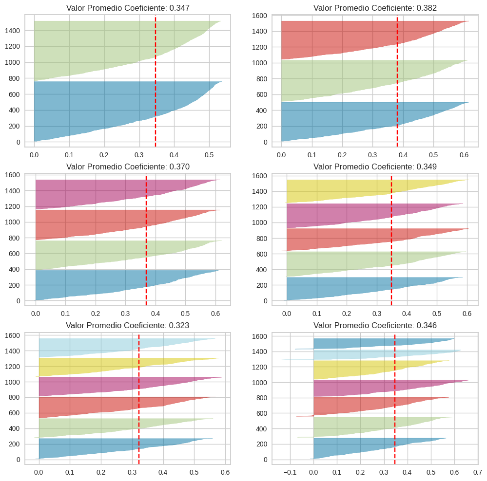

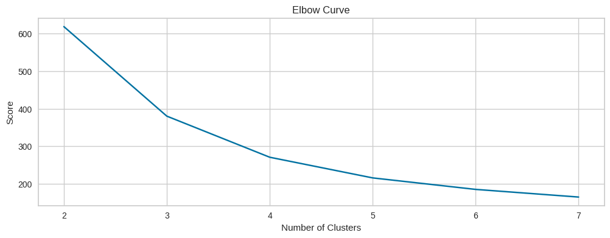

```python
# Para el dataset 4

# Seleccionamos un rango de clusters a analizar
n_clusters = [2, 3, 4, 5, 6, 7]

fig, ax = plt.subplots(3, 2, figsize=(12, 12))
scores = []
for c in n_clusters:
    # Definimos el método KMeans
    km = KMeans(n_clusters=c, init='k-means++', n_init=10, random_state=123)
    q, mod = divmod(c, 2)
    km.fit(X_circle)

    # Recolectamos en un vector los valores de inertia
    scores.append(km.inertia_)

    # Calculamos el silhouette score y mostramos su gráfica
    score = silhouette_score(X_circle, km.labels_, metric='euclidean')
    visualizer = SilhouetteVisualizer(km, colors='yellowbrick', ax=ax[q - 1][mod])
    leyenda = "Valor Promedio Coeficiente: %.3f" % (score)
    visualizer.set_title(leyenda)
    visualizer.fit(X_circle)

plt.show()

# Graficamos los valores de inertia para cada número de cluster
plt.figure(figsize=(12, 4))
plt.xlabel('Number of Clusters')
plt.ylabel('Score')
plt.title('Elbow Curve')
plt.plot(n_clusters, scores)
plt.show()
```

### Pregunta 5: Redacta de la manera más específica las conclusiones que puedes sacar con las gráficas para cada una de las bases de datos

Consideramos un número de cluster correcto cuando el gráfico silhouette presenta estas características:

- El valor promedio es lo más cercano posible a 1.

- Los clusters presnetan una forma de hoja de cuchillo y no cónica

- El pico de la hoja de cuchillo se encuentra por encima de el valor promedio.

Por tanto, el los tres primeros dataset consideramso que el número de cluster más adecuado son 2 o 3 ya que estos cumplen las condiciones anteriores. Si tuviesemos que escoger uno elegiríamos dividir en 2 clusters a que su valor promedio es el más cercano a 1.

En el dataset 4 observamos que la división es igual de mala para cualquier número de clusters. Por lo que elegimos dividir en tres grupos ya que es el que mayor valor promedio teiene.

# c) Desbalance de los datos:

Explicaremos a continuación como el algoritmo puede ser susceptible a la cantidad de muestras de cada clase. Trabajaremos con el dataset 3, utilizaremos una herramienta llamada SMOTE que genera datos sintéticos interpolando los ya existentes. **Muestra la gráfica con los datos X_balanced y y_balanced, explica lo que ves y compara con la figura de este mismo dataset.**

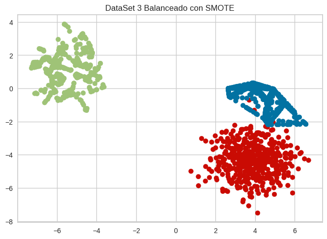

```python
# Se utilizó SMOTE para balancear el dataset 3
X_balanced, y_balanced = SMOTE(random_state=123).fit_resample(X_filtered, y_filtered)

# Definir colores para las clases
colors = ['r', 'g', 'b']

# Mostrar el dataset balanceado con colores para las clases
plt.scatter(X_balanced[:, 0], X_balanced[:, 1], c=[colors[i] for i in y_balanced])
plt.title('DataSet 3 Balanceado con SMOTE')
plt.show()
```

### Pregunta 6: ¿En que cambió el data set? Explica lo que ves en la figura que has creado, intenta visualizar que ha hecho el método SMOTE y explicalo.

Antes teniamos un grupo donde había poca cantidad de puntos (muestras), SMOTE ha aumentado la representación de ese grupo sin replicar ya existentes. Para cada grupo minoritario, selecciona los k ejemplos vecinos más cercanos de ese mismo grupo, y genera datos sintéticos interpolando características entre el dato original y el vecino seleccionado.

En los clusters donde había menos puntos ha generado nuevos puntos mediante una interpolación entre los puntos ya existentes.

**Aplica el algoritmo de `KMeans` y muestra el resultado de las predicciones**

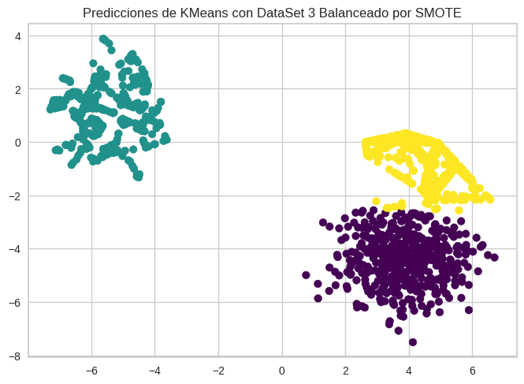

```python
#continua el codigo aqui aplicando Kmean al dataset balanceado y muestra las predicciones

kmeans = KMeans(n_clusters=3, random_state=123, init='k-means++')
y_pred = kmeans.fit_predict(X_balanced)

# Mostrar la gráfica con los datos y las predicciones
plt.scatter(X_balanced[:, 0], X_balanced[:, 1], c=y_pred, cmap='viridis')
plt.title('Predicciones de KMeans con DataSet 3 Balanceado por SMOTE')
plt.show()
```

### Pregunta 7: ¿Como es ahora el agrupamiento?, respecto a no utilizar SMOTE

Ahora el resultado es mucho mejor dado que la clusterización separa entre los tres clusters originales, no como estaba agrupado anteriormente, donde agrupaba dos cluster en uno y separaba el nuevo cluster por la mitad.

# d) Limitaciones de forma:

Para finalizar con ayuda de la documentación del metodo K-mean, **Explora diferentes configuraciones para trabajar con la base de datos 4.**

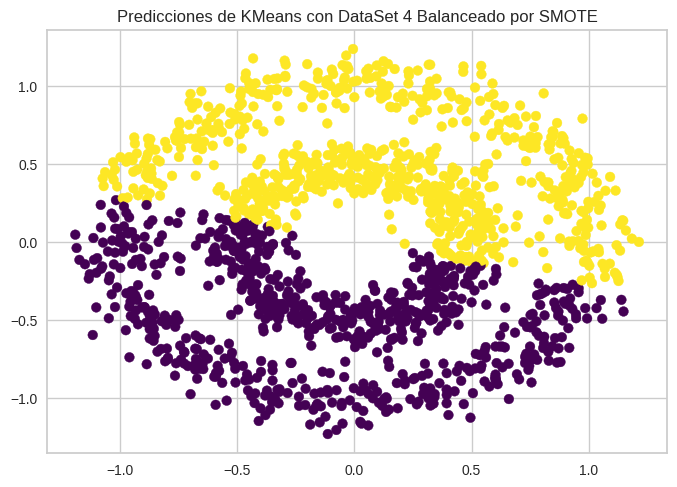

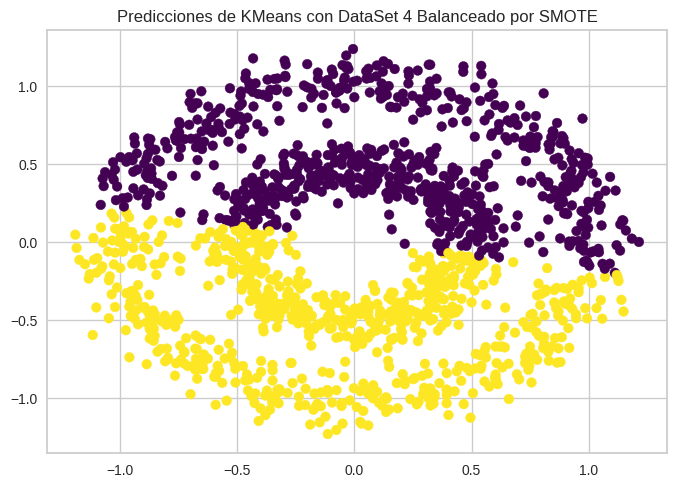

```python
#continua el codigo aqui agrega tantos experimentos como sean necesarios para explicar tus resultados

# APLICAREMOS SMOTE Y K-MEANS AL DATASET 4

# usando k-means++

from imblearn.over_sampling import SMOTE
from sklearn.cluster import KMeans
import matplotlib.pyplot as plt

# Usamos SMOTE para balancear el dataset
X_balanced_circle, y_balanced_circle = SMOTE(random_state=123).fit_resample(X_circle, y_circle)
# Aplicamos K-means
kmeans_circle = KMeans(n_clusters=2, random_state=123, init='k-means++')
y_pred_circle = kmeans_circle.fit_predict(X_balanced_circle)
plt.scatter(X_balanced_circle[:, 0], X_balanced_circle[:, 1], c=y_pred_circle, cmap='viridis')
plt.title('Predicciones de KMeans con DataSet 4 Balanceado por SMOTE')
plt.show()

# usando random

# Usamos SMOTE para balancear el dataset
X_balanced_circle, y_balanced_circle = SMOTE(random_state=123).fit_resample(X_circle, y_circle)

# Aplicamos K-means
kmeans_circle = KMeans(n_clusters=2, random_state=123, init='random')
y_pred_circle = kmeans_circle.fit_predict(X_balanced_circle)
plt.scatter(X_balanced_circle[:, 0], X_balanced_circle[:, 1], c=y_pred_circle, cmap='viridis')
plt.title('Predicciones de KMeans con DataSet 4 Balanceado por SMOTE')
plt.show()
```